# Étude du questionnaire motivation et ambiance en Licence d’économie

Approche sur les relations entre la vie étudiante et les choix post-licence

Léa BRASSEUR & Neil DUPIN

**Le projet futur de l’étudiant influence-t-il son comportement, ses notes et ses ressentis en licence d’économie ?**

Nous cherchons à étudier si le fait que l’étudiant ait une idée de son futur métier influence ses choix en licence. Nous nous demandons s’il y a une corrélation entre les notes, la motivation et les idées de l’étudiant sur son avenir.

- Dans un premier temps, nous allons présenter l’axe choisi en nous focalisant seulement sur les réponses à la question : Savez-vous quel métier voulez-vous faire plus tard ?
- Dans un deuxième temps, nous allons observer la relation entre les années d’études et les décisions futures de l’étudiant à l’aide des données portant sur les années de licence des répondants.
- Ensuite, nous regarderons l’investissement des étudiants et leur intégration au sein de la licence en fonction de leur choix futur. Les variables utilisées ici seront celles sur leur motivation, sur leurs avis sur les cours suivis, sur le travail en groupe et enfin, sur la proportion d’étudiants cotoyés.
- Et pour finir, nous analyserons le lien entre les choix futurs de l’étudiant et ses notes. Nous interprèterons leurs moyennes globales sur l’année (grâce à la variable NOTE) et leur moyennes dans des matières spécifiques tels que la microéconomie, la macroéconomie, les statistiques et les mathématiques.

# Introduction

Les idées pour le futur métier

| . | Freq |
| --- | --- |
| Non | 85 |
| Oui | 61 |
| Sum | 146 |

Les analyses suivantes vont portées pour la plupart sur les réponses des 146 étudiants.

Fréquence des réponses à la question sur le métier futur

| . | Freq |
| --- | --- |
| Non | 0.582 |
| Oui | 0.418 |

Pour commencer, nous pouvons voir que les réponses des étudiants à la question “Savez-vous quel métier voulez-vous faire plus tard ?” ne sont pas réparties de manière égales mais les résultats obtenues vont quand même nous permettre d’analyser correctement les données car elles ne sont pas trop éloignées. En effet, 58% d’étudiants n’avaient pas, au moment où ils ont répondu aux questions, d’idée fixe sur le métier qu’ils souhaiteraient exercer après leurs études.

# Le futur métier et l’année d’étude

Tout d’abord, nous nous demandons si l’avancée dans les études permet à l’étudiant de concrétiser ses projets et par conséquent d’avoir une idée plus précise du métier qu’il voudrait faire par la suite.

Répartition des réponses en fonction des années de licence

|  | L1 | L2 | L3 | Sum |
| --- | --- | --- | --- | --- |
| Non | 40 | 23 | 22 | 85 |
| Oui | 30 | 13 | 18 | 61 |
| Sum | 70 | 36 | 40 | 146 |

Ce premier tableau nous permet d’avoir le nombre de répondants pour chaque années d’études en fonction de la question sur les métiers. Grâce à ce premier tableau nous allons pouvoir en créer un second avec les fréquences des réponses en fonction de l’année d’étude.

Répartition des fréquences en fonction des années de licence

|  | L1 | L2 | L3 |
| --- | --- | --- | --- |
| Non | 0.57 | 0.64 | 0.55 |
| Oui | 0.43 | 0.36 | 0.45 |

Dans ce second tableau, si nous comparons les résultats obtenus dans les colonnes corespondants aux premières et aux deuxièmes années, ils ne sont pas ceux auxquels nous nous attendions car la proportion de L2 ayant une idée sur leur futur métier est inférieure à la proportion de L1. En revanche, si nous prenons les colonnes 2 et 3, nous pouvons voir que la proportion de L3 ayant répondue OUI est supérieure à la proportion de L2. Pour ce qui est de la première et de la troisème colonnes, les résultats sont semblables.

Ces résultats ne nous permettent pas de conclure que le niveau d’étude et les projets futurs sont liés puisque les résultats de la deuxième ligne ne sont pas croissants.

# Le futur métier, la motivation et l’intégration dans la licence

Dans cette partie, nous allons étudier la corrélation entre la motivation et les ambitions futures des étudiants.

## Les ressentis en licence

- *Les enseignements*

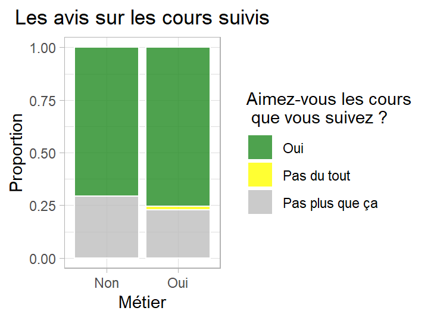

Nous pouvons voir que la plupart des étudiants apprécient les cours qu’ils suivent car la part de OUI (représentée par la couleur verte) est la plus importante, autant pour les personnes ayant des projets d’avenir concrets que pour les autres. De plus, les résultats pour les deux groupes sont relativement égaux. Nous pouvons donc dire que les ambitions futures n’influencent pas l’avis sur les cours suivis.

- *La motivation*

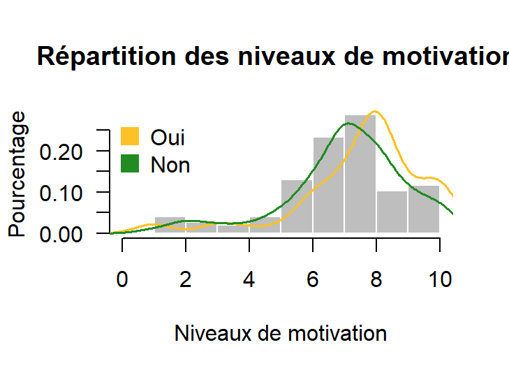

Nous pouvons constater que la courbe jaune est légérement plus décalée sur le côté droit, ce qui veut dire que les étudiants ayant votés OUI au sondage sur le métier futur ont une motivation légèrement supérieure à ceux ayant votés NON.

## La vie associative et sociale

- *Vie associative*

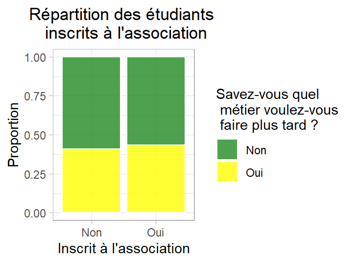

| Min.eff.théo | p-value | Taille de l’échantillon |
| --- | --- | --- |
| 19.2 | 0.919 | 146 |

Le graphique nous permet de voir que les répartitions des étudiants au sein des deux colonnes sont quasiment identiques. C’est-à-dire, que l’orientation futur de l’étudiant n’influence pas son implication au sein de l’association. De plus, le test nous permet de confirmer les conclusions obtenues grâce au graphique. La p-value étant de 0.919, au risque 5% nous ne pouvons pas rejeter l’hypothèse nulle, les 2 variables sont donc indépendantes.

- *Vie sociale*

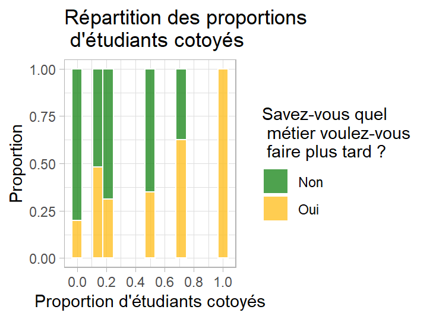

Ce graphique nous permet de voir qu’il y a une certaine relation entre la proportion d’étudiants cotoyés et l’avenir de l’étudiant. En effet, nous voyons bien que les étudiants cotoyant le plus de personnes sont les étudiants qui savent quel métier faire après leurs études.

## Le travail en groupe

Dans cette sous-partie, nous nous demandons si avoir une idée de son futur métier influence l’étudiant à travailler en groupe. Pour cela nous allons réaliser un test d’indépendance.

| Min.eff.théo | p-value | Taille de l’échantillon |
| --- | --- | --- |
| 7.1 | 0.25 | 146 |

Nous obtenons une p-value = 0.25. Donc, au risque 5%, nous ne rejetons pas l’hypothèse nulle car p-value = 0.25 > alpha = 0.05. Ce qui veut dire que les variables “Métier” et “Travail en groupe” sont indépendantes. Le fait de savoir vers quel métier s’orienter après ses études n’influence pas l’étudiant à travailler en groupe durant sa licence.

# Le futur métier et les notes en L1

Dans cette partie, nous allons étudier la relation entre les notes des étudiants de première année et leur choix de métier post-licence. La question que nous nous posons ici est de savoir si les étudiants ayant une idée de leur futur métier obtiennent des notes plus élevés.

- *Le nombre de répondants en L1*

Répartition des réponses en fonction des années de licence

|  | L1 | L2 | L3 | Sum |
| --- | --- | --- | --- | --- |
| Non | 40 | 23 | 22 | 85 |
| Oui | 30 | 13 | 18 | 61 |
| Sum | 70 | 36 | 40 | 146 |

Nous pouvons voir qu’il y eu 70 répondants en L1 et que 30 d’entre eux ont répondu qu’ils savaient quel métier faire après leurs études. Seul ces 70 répondants vont nous intéresser pour cette partie car nous n’avons pas les notes des 76 autres.

- *Les moyennes par matières*

Comparaison des résultats sur l’année

|  | Non | Oui |
| --- | --- | --- |
| Micro | 10.97 | 11.28 |
| Macro | 11.36 | 12.42 |
| Maths | 5.85 | 6.59 |
| Stat | 10.42 | 11.20 |

Nous pouvons voir que dans les 4 matières principales de la licence d’économie, qui sont Microéconomie, Macroéconomie, Mathématiques et Statistiques, les étudiants ayant répondu OUI à la question portant sur le choix de leur futur métier ont des moyennes plus élevées que ceux ayant répondu NON.

Mais les écarts entre les notes des deux colonnes ne sont pas très élevés nous nous demandons si globalement la moyenne générale des étudiants ayant répondu OUI est plus élevée que celle de ceux ayant répondu NON ?

```
##
##  Shapiro-Wilk normality test
##
## data:  data$NOTE[data$Métier == "Oui"]
## W = 0.97984, p-value = 0.923
```

```
##
##  Shapiro-Wilk normality test
##
## data:  data$NOTE[data$Métier == "Non"]
## W = 0.97886, p-value = 0.7801
```

| Non | Oui | Var.égales | mean in group Non | mean in group Oui | Borne inf. IC95 | Borne sup. IC95 | p-value |
| --- | --- | --- | --- | --- | --- | --- | --- |
| 31 | 21 | oui | 10.48 | 10.98 | -1.93 | 0.93 | 0.49 |

Les données selectionnées ici concernent seulement 52 étudiants car les autres étudiants ont été défaillants, ils n’ont donc pas eu de moyenne définitive sur leur année.

Nous obtenons dans le tableau une p-value égale à 0.49. Donc au risque de 5%, nous ne rejetons pas H0 car p-value = 0.49 > 0.05. Ce qui veut dire que globalement les moyennes générales des étudiants des 2 groupes sont considérées comme égales. L’écart trouver grâce au tableau précédent n’est donc pas significatif.

- *La validation des matières fondamentales*

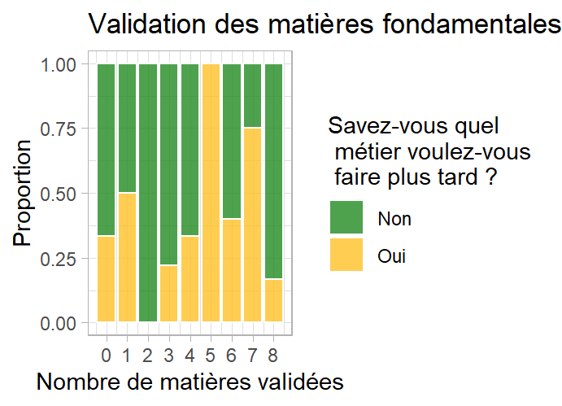

Nous avons étudiés ici les validations des matières fondamentales (microéconomie, macroéconomie, statistiques et mathématiques) sur les 2 semestres de l’année. Le graphique ne nous permet pas de dire si une corrélation existe entre la décision sur le métier futur et le nombre de matières fondamentales validées. Effectivement, pour les valeurs allant de 2 à 7, une corrélation positive entre le choix du futur métier et le nombre de matières validées est possible. Mais pour les valeurs 0,1 et 8, cette corrélation ne se vérifie pas.

# Conclusion

Pour rappel, la problématique étudiée ici est : **le projet futur de l’étudiant influence-t-il son comportement, ses notes et ses ressentis en licence d’économie ?**

Tout d’abord, les résultats obtenus ne sont pas forcément ceux auxquels nous nous attendions. En effet, nous avons pu constater que le fait que les étudiants aient des projets d’avenir concrets n’influencent pas ou peu leurs vies étudiantes.

Les résultats obtenus nous montre que les projets ne se concrétisent pas forcément avec l’avancée dans les études.

De plus, le fait d’avoir une idée précise du métier futur n’influence pas l’avis sur les cours suivis. Les idées d’avenir ont un léger impact sur la motivation. En revanche, les inscriptions à l’association ne sont pas plus nombreuses. Par ailleurs, nous avons pu noter une légère corrélation entre la proportion d’étudiants cotoyés et les ambitions futures, mais cette corrélation ne s’est pas poursuivie au niveau du travail en groupe. Dans ce cas les étudiants se cotoieraient seulement pour l’aspect social et non pour l’aspect travail.

Et pour terminer, les notes et les résultats sont globalement les mêmes, peu importe les projets d’avenir.

Ceci nous permet donc de dire qu’il n’y a pas de réelles différences entre les étudiants ayant des ambitions concrètes et ceux n’en n’ayant pas.